# 每週一圖作業範例

#### 環境設定

以下為老師執行時一定會存在的環境設定

```r
Sys.setlocale("LC_ALL","Chinese")  #解決中文亂碼問題
```

```
## [1] "LC_COLLATE=Chinese (Simplified)_China.936;LC_CTYPE=Chinese (Simplified)_China.936;LC_MONETARY=Chinese (Simplified)_China.936;LC_NUMERIC=C;LC_TIME=Chinese (Simplified)_China.936"
```

```r
library(dplyr); library(stringr); library(ggplot2); library(plotly); library(lubridate); library(readr); library(tidyr); library(showtext);library(ggthemes);library(tidyselect); library(grDevices) # 不同顏色模型代碼的呈現及轉換
library(scales) # show_col()螢幕立即顯示顏色
library(colorspace) # 調色盤選擇及ggplot應用工具
library(shinyjs) # 支援套件
library(magrittr)
library(ggforce)


font_add("QYuan","cwTeXQYuan-Medium.ttf") # 新增字體
showtext_auto(enable=TRUE) #啟用字體
theme_set(theme_classic())
knitr::opts_chunk$set(out.width='80%', fig.asp=.75, fig.align='center', fig.showtext=T)
```

#### 資料處理

此部份在做：

- 原始Rda資料引入（即引入**dataList**物件）；
- 資料清理成作圖用graphData物件。

請將你最原始的資料連同作業一起上傳到作業上傳網址：  
* 若「原始資料為網頁下載」，且下載指令寫在data cleaning chunk裡的話，可以不用上傳「資料」。  
* 若原始資料有很多個檔案，請先引入成data frame並存在「一個」.Rda檔裡上傳（如`example_data.Rda`檔）。

資料檔引入到進入作圖前的資料處理請寫在下面區塊，分二部份：

- 資料處理
- 作圖用資料物件生成

```r
# 資料引入
# 資料處理
data_0 <- read_csv("C:/Users/Leo jay/Desktop/123123.csv",locale = locale(encoding = "BIG5"))
dataList <- list()
data_0$行業別 <- as.factor(data_0$行業別)

levels(data_0$行業別)
```

```
##  [1] "不動產業"                       "產業用機械設備維修及安裝業"
##  [3] "成衣及服飾品製造業"             "電力及燃氣供應業"
##  [5] "電力設備製造業"                 "電腦、電子產品及光學製品製造業"
##  [7] "電子零組件製造業"               "紡織業"
##  [9] "非金屬礦物製品製造業"           "公共行政及國防；強制性社會安全"
## [11] "化學材料製造業"                 "化學製品製造業"
## [13] "基本金屬製造業"                 "機械設備製造業"
## [15] "家具製造業"                     "教育服務業"
## [17] "金融及保險業"                   "金屬製品製造業"
## [19] "礦業及土石採取業"               "木竹製品製造業"
## [21] "農、林、漁、牧業"               "批發及零售業"
## [23] "皮革、毛皮及其製品製造業"       "其他服務業"
## [25] "其他運輸工具製造業"             "其他製造業"
## [27] "汽車及其零件製造業"             "石油及煤製品製造業"
## [29] "食品製造業"                     "塑膠製品製造業"
## [31] "橡膠製品製造業"                 "菸草製造業"
## [33] "藥品製造業"                     "醫療保健及社會工作服務業"
## [35] "藝術、娛樂及休閒服務業"         "飲料製造業"
## [37] "印刷及資料儲存媒體複製業"       "營造業"
## [39] "用水供應及污染整治業"           "運輸及倉儲業"
## [41] "支援服務業"                     "紙漿、紙及紙製品製造業"
## [43] "住宿及餐飲業"                   "專業、科學及技術服務業"
## [45] "資訊及通訊傳播業"
```

```r
#data_0 %>%  filter( grepl("製造業", 行業別))

data_0 %>% mutate(
  工作領域 = as.factor(
    case_when
    (
    grepl("製造業", 行業別)                      |grepl("批發及零售業", 行業別)          |grepl("產業用機械設備維修及安裝業", 行業別)
    |grepl("運輸及倉儲業", 行業別)               |grepl("資訊及通訊傳播業", 行業別)      |grepl("營造業", 行業別)
    |grepl("用水供應及污染整治業", 行業別)       |grepl("農、林、漁、牧業", 行業別)      |grepl("印刷及資料儲存媒體複製業", 行業別)
    |grepl("礦業及土石採取業", 行業別)           |grepl("電力及燃氣供應業", 行業別)      |grepl("紡織業", 行業別) ~"第一、二級產業",

    grepl("服務業", 行業別)         |grepl("住宿及餐飲", 行業別)                             ~ "第三級產業",
    grepl("不動產業", 行業別)| grepl("金融及保險業", 行業別)                                ~ "金融保險及不動產"    ,
#    grepl("公共行政及國防；強制性社會安全", 行業別)                                         ~ "公共行政及軍警",

    TRUE ~ as.character(行業別) )
  )
)       ->  data_1



data_1[-3]  ->dataList$sub0
dataList$sub0[-1] ->dataList$sub

dataList$sub %>% group_by(
  受傷部位,工作領域
) %>% summarise(
  受傷部位次數=sum(受傷部位次數)
) ->dataList$a





dataList$a$受傷部位 <- as.factor(dataList$a$受傷部位)
levels(dataList$a$受傷部位)
```

```
##  [1] "背"   "腹"   "股"   "肩"   "頸"   "肋骨" "臉顏" "內臟" "其他" "前膊"
## [11] "全身" "上膊" "手"   "鼠蹊" "鎖骨" "頭"   "腿"   "臀"   "腕"   "胸"
## [21] "指"   "肘"   "足"
```

```r
dataList$a %>% mutate(
  受傷部位=as.factor(
    case_when(
    受傷部位=="背"    |受傷部位=="腹"    |受傷部位=="肩"    |受傷部位=="肋骨"  |受傷部位=="前膊"  |受傷部位=="上膊"
    |受傷部位=="手"   |受傷部位=="胸"    |受傷部位=="腕"    |受傷部位=="指"    |受傷部位=="肘"    |受傷部位=="足"
    |受傷部位=="股"   |受傷部位=="臀"    |受傷部位=="腿"    |受傷部位=="鼠蹊"       ~"身體(頭部以下)",

    受傷部位=="頭"    |受傷部位=="頸"    |受傷部位=="臉顏"  |受傷部位=="鎖骨"       ~"頭頸",
    受傷部位=="內臟"  ~"內臟",
    TRUE ~ "0000")  )
                    )    ->dataList$b0
```

[output not shown]

```r
dataList$b0 %>% group_by(
  受傷部位,工作領域
) %>% summarise(
  受傷部位次數=sum(受傷部位次數)
) %>% ungroup    ->dataList$b1
graphData<-list()
dataList$b1[-(1:4),]   ->dataList$b2
dataList$b2[-3,]->dataList$b3
dataList$b3[-6,]->dataList$b4
dataList$b4[-9,]->dataList$b5

dataList$b5$工作領域=factor(dataList$b5$工作領域,levels = c("第一、二級產業","第三級產業","金融保險及不動產"))

dataList$b5$受傷部位 <- as.factor(dataList$b5$受傷部位)


dataList$b5   -> graphData$data

#graphData$data %>% View()
# dataList$b[(1:4),]    ->dataList$inOrgan
# dataList$b[(5:8),]    ->dataList$body
# dataList$b[(9:12),]   ->dataList$head



#   作圖用資料物件生成：處理好可進行作圖的資料請存在一個名為graphData的list物件裡
```

#### 繪圖程式

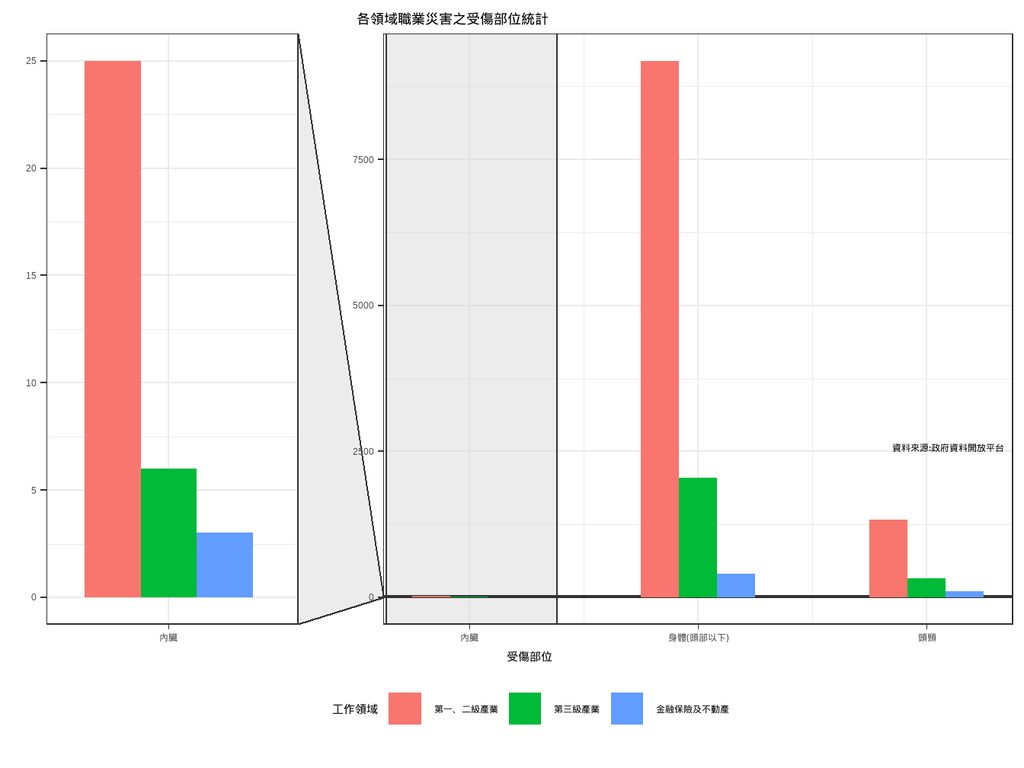

```r
graphData$data %>% ggplot(
  aes(x= as.numeric(受傷部位),y=受傷部位次數,fill=工作領域)
)+geom_col(
  position = "dodge",width=0.5,
  )+labs(
  x = "受傷部位", y = "",
  title="各領域職業災害之受傷部位統計",
  caption ="資料來源:政府資料開放平台"
 # tag="單位: 次"
  ) + facet_zoom(
    y = 受傷部位 %in% c("內臟"), horizontal = T, xlim = c(0.67, 1.35),zoom.size=0.4 , show.area = T
    )+ scale_x_continuous(
    breaks = 1:length(levels(graphData$data$受傷部位)),
    label = levels(graphData$data$受傷部位),
 )+
  theme_bw()+
  theme(
    axis.ticks.x =   element_line(size = 0),
    axis.title.x = element_text(vjust=-1),
    plot.title = element_text(hjust = 0.4,vjust=-0.2),
    legend.position="bottom",
    plot.caption =element_text(hjust=0.99,vjust =+165 ),
  #  panel.grid.minor = element_blank()
  )
```

```r
 # plot.tag =element_text(hjust=-60,vjust = -4)

#  annotation_custom(grob = grid::textGrob("單位: 次"),xmin = 3, xmax = 3, ymin = 5200, ymax = 5200)
# annotate("text", x = 0.8, y = 500, label = "單位: 次")



#    scale  palete  theme(
#    panel.grid.minor = element_blank(),            #remove the grid of legend
#    plot.caption = element_text(hjust = +1),       #plot.=element_text(.just=)   移動位子
#    plot.title = element_text(hjust =-0.05))
```

#### 設計說明

此圖呈現在不同工作領域下，工作者遭遇到到的職業災害次數比較,體現在不同身體部位。

補充:由於資料為“上網”填報的數據，故第一級產業統計到的次數較少,與其他兩類懸殊甚大，無法在圖型顯現出差異性,又第一、二級產業職業災害發生頻率較於第三級產業頻繁，故將第一、二級產業計算在一起,與第三級產業,以及北大經濟學系的學生未來出路較相關的“金融保險及不動產”，一起進行比較。

*資料整理: 原始資料為民國103年，不同領域的工作者“上網”通報於職災網路系統的統計數據，分成不同身體部位計數。

原址資料其受傷害的身體部位，分類共有二十三種，在此分成“內臟”、“身體(頭部以下)”，以及“頭頸”，主要是因為四肢及身體受傷的發生情況相似，而頭頸及內臟較不容易從其工作環境判別。

原始資料雖然沒有提到身體部位受傷的程度，但從經驗及現實角度來看，通報職災訊息往往要經過繁雜的行政程序，再加上傷者可能迫於主管單位的壓力下自行處理，所以大致上除了情節嚴重者外，其他輕傷往往會被忽略而沒有上報系統，導致資料沒有辦法完全呈現該行業的受傷狀況。 但我們仍可以預期，就算只是情節較嚴重的職災，服務業及金融保險不動產，這類需要付出勞力較低的工作者，發生職業傷害的頻率仍會低於第一、二級產業，而第三級產業又會高於金融保險業，在此可從圖型看出，差異確實存在。